# So will I lyrics - Exploratory Analysis #Hillsong

Elikplim Sabblah

2/19/2021

This is a simple exploratory analysis of the Lyrics of Hillsong’s **So will I** lyrics. It is a very powerful worship song that makes good use of imagery and proclamations that worshipers can easily connect to. This analysis just seeks to take a deep dive into the lyrics via some data analytic functions. It is mostly characterized by count of words under different themes.

Reading load the data into R markdown to commence the analysis

```r
Lyrics <- read.csv("C:\\Users\\PAS\\Documents\\Lyrics.csv", header = TRUE, stringsAsFactors = FALSE)
```

Also, let us load all the libraries that we will need to do the analysis

```r
library(tidyverse)
```

```r
library(tidytext)
library(wordcloud2)
```

Firstly, let us take a look at the data itself.

```r
head(Lyrics)
```

```
##   Lines                                Text
## 1     1                     God of creation
## 2     2                  There at the start
## 3     3        Before the beginning of time
## 4     4          With no point of reference
## 5     5               You spoke to the dark
## 6     6 And fleshed out the wonder of light
```

To be able to analyze the lyrics according to individual words, we need to tokenize the text in the data - in this case, the lyrics. Tokenization is essentially splitting a phrase, sentence, paragraph, or an entire text document into smaller units, such as individual words or terms.This helps us do the analysis according to portions of the text that we desire to use.

## Tokenizing the words of the lyrics

```r
Lyrics_1 <- Lyrics %>%
  unnest_tokens(word, Text)
head(Lyrics_1)
```

```
##     Lines     word
## 1       1      god
## 1.1     1       of
## 1.2     1 creation
## 2       2    there
## 2.1     2       at
## 2.2     2      the
```

## Counting the number of words in the Lyrics

```r
Lyrics_2 <- Lyrics_1 %>%
  count(word, sort = TRUE)
head(Lyrics_2)
```

```
##   word  n
## 1    i 20
## 2  you 20
## 3  the 19
## 4   so 16
## 5   of 15
## 6 will 15
```

## Visualizing total number of words and unique words

```r
Totals <- c("Total Number of Words", "Total Number of Unique Words")
Number <- c(389, 168)
Lyrics_count <- data.frame(Totals, Number)
head(Lyrics_count)
```

```
##                         Totals Number
## 1        Total Number of Words    389
## 2 Total Number of Unique Words    168
```

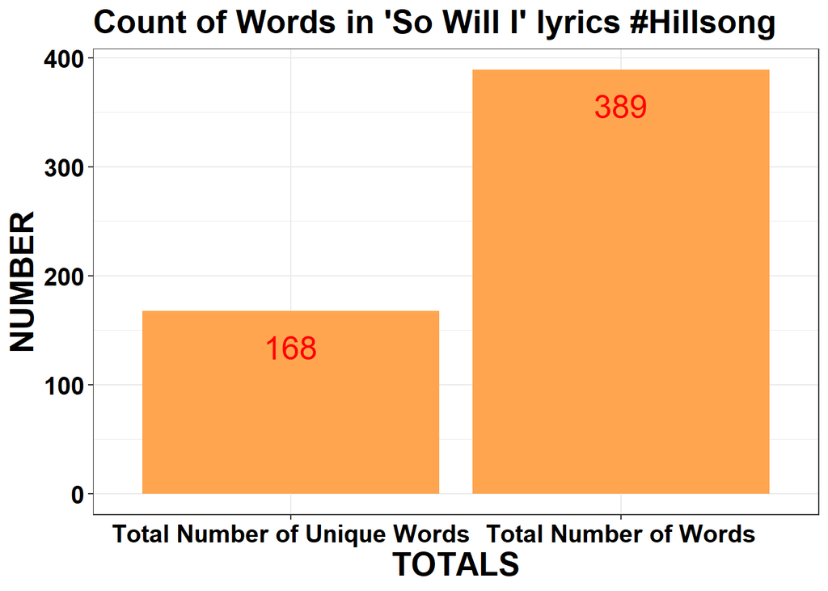

```r
Lyrics_count %>%
  ggplot(aes(Totals, Number))+
  geom_bar(stat = "identity", fill = "tan1")+
  theme_bw() +
  geom_text(aes(label = Number), vjust = 2, colour = "red", size = 7) +
  labs(x = "TOTALS", y = "NUMBER", title = "Count of Words in 'So Will I' lyrics #Hillsong") +
  theme(axis.text=element_text(size=15, face = "bold", colour = "black"),axis.title=element_text(size=20,face="bold"))+
  theme(plot.title = element_text(size = 20, face = "bold"))
```

## Sentiments Analysis

```r
Lyrics_3 <- Lyrics_1 %>%
  inner_join(get_sentiments("nrc")) %>%
  count(word, sentiment, sort = TRUE)
```

## Making the word cloud

```r
wordcloud2(Lyrics_2)
```

[interactive chart not shown]

## Making bar graph including stop words

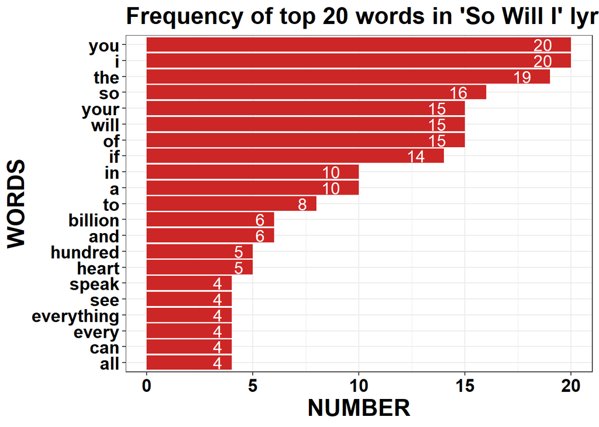

```r
Lyrics_2 %>%
  top_n(20) %>%
  ggplot(aes(reorder(word, n), n)) +
  geom_col(fill = "firebrick3") +
  coord_flip() +
  geom_text(aes(label = n), hjust = 2, colour = "white", size = 5) +
  theme_bw() +
  labs(x = "WORDS", y = "NUMBER", title = "Frequency of top 20 words in 'So Will I' lyrics #Hillsong") +
  theme(axis.text=element_text(size=15, face = "bold", colour = "black"),axis.title=element_text(size=20,face="bold"))+
  theme(plot.title = element_text(size = 20, face = "bold"))
```

## Making bar graph excluding stop words

```r
Lyrics_4 <- Lyrics_1 %>%
  anti_join(stop_words)%>%
  count(word,sort = TRUE)
```

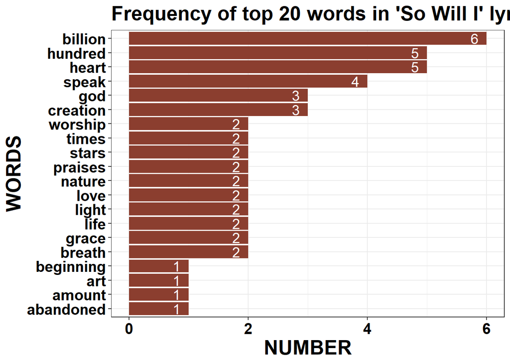

```r
Lyrics_4[1:20,] %>%
  ggplot(aes(reorder(word, n), n)) +
  geom_col(fill = "coral4") +
  coord_flip() +
  geom_text(aes(label = n), hjust = 2, colour = "white", size = 5) +
  theme_bw() +
  labs(x = "WORDS", y = "NUMBER", title = "Frequency of top 20 words in 'So Will I' lyrics (without stopwords) #Hillsong") +
  theme(axis.text=element_text(size=15, face = "bold", colour = "black"),axis.title=element_text(size=20,face="bold"))+
  theme(plot.title = element_text(size = 20, face = "bold"))
```

## Bar graph to visualize the sentiments expressed in the lyrics

```r
Lyrics_5 <- Lyrics_1 %>%
  inner_join(get_sentiments("bing")) %>%
  count(word, sentiment, sort = TRUE)
```

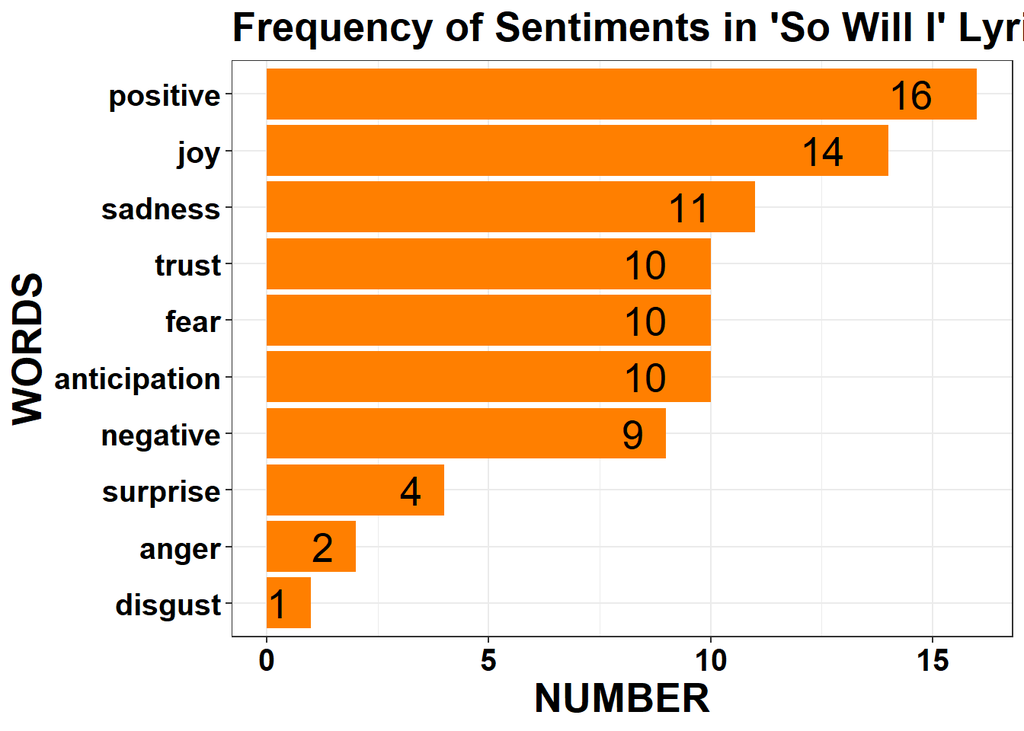

```r
Lyrics_6 <- Lyrics_3 %>% count(sentiment)
colnames(Lyrics_6) <- c("Sentiment", "Number")


Lyrics_6 %>%
  ggplot(aes(reorder(Sentiment, Number), Number)) +
  geom_col(fill = "darkorange1") +
  coord_flip() +
  geom_text(aes(label = Number), hjust = 2, colour = "black", size = 7) +
  theme_bw() +
  labs(x = "WORDS", y = "NUMBER", title = "Frequency of Sentiments in 'So Will I' Lyrics #Hillsong") +
  theme(axis.text=element_text(size=15, face = "bold", colour = "black"),axis.title=element_text(size=20,face="bold"))+
  theme(plot.title = element_text(size = 20, face = "bold"))
```